# module3

## Comparing Sample Distributions

#### Objectives:

- Use visuals to perform simple comparison between two or more sample
- Use numerical values to perform simple comparison between two or more sample

#### Why?

In public health, it's often the case that we want to make a comparison between groups. For intance, we might be interested in finding out if there is a difference between the average body mass index of populations within certain age groups.

```python
import matplotlib.pyplot as plt
import numpy as np
import pandas as pd
%matplotlib inline
```

Let's use Body Mass Index (BMI) data for illustration

```python
data = pd.read_csv('breast.txt')
cols = [name.replace("'","") for name in data.columns]
data.columns = cols
data = data[data['case']==0][['age','bmi']]
data.head()
```

|  | age | bmi |
| --- | --- | --- |
| 0 | 47 | 26 |
| 1 | 54 | 26 |
| 2 | 53 | 28 |
| 3 | 58 | 29 |
| 4 | 64 | 32 |

```python
# A quick summary statistics
data.describe()
```

|  | age | bmi |
| --- | --- | --- |
| count | 1146.000000 | 1146.000000 |
| mean | 58.628272 | 26.157941 |
| std | 5.933669 | 4.993307 |
| min | 43.000000 | 13.000000 |
| 25% | 54.000000 | 23.000000 |
| 50% | 59.000000 | 25.000000 |
| 75% | 63.000000 | 29.000000 |
| max | 70.000000 | 49.000000 |

The minimum age is 43 years old and the maximum age is 70. We would like to find out if there is a significant difference in BMI between individuals aged less than or equal to 50 years and individuals above 50.

```python
#Let's create a label to separate the groups
def test(x):
    if x<=50: return 1
    return 0

data['age<=50'] = data['age']
data['age<=50'] = list(map(test , data['age']))
data.head()
```

|  | age | bmi | age<=50 |
| --- | --- | --- | --- |
| 0 | 47 | 26 | 1 |
| 1 | 54 | 26 | 0 |
| 2 | 53 | 28 | 0 |
| 3 | 58 | 29 | 0 |
| 4 | 64 | 32 | 0 |

#### Visual Inspection

Now we can use a boxplot to make a visual inspection of the difference in BMI across age groups.

```
Text(0.5,1,'Body Mass Index')
```

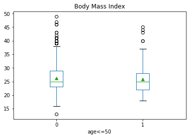

```python
data.boxplot(column='bmi', by='age<=50', showmeans=True, grid=False)
#suppress aytomatic title
plt.suptitle('')
plt.title('Body Mass Index')
```

```
array([<matplotlib.axes._subplots.AxesSubplot object at 0x7f7e9d38ca20>,
      dtype=object)
```

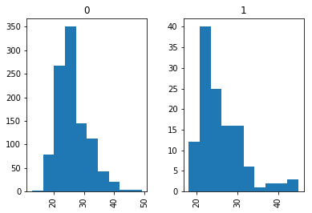

```python
#use histograms to visualize the data for the two groups
data.hist(column='bmi', by='age<=50', grid=False)
```

#### Numerical Inspection

We can also calculate summary statistics to quantify the differences between the groups. We can

- Compare the means
- Compare the median
- Compare percentiles
- etc

```python
#comparing means
data.groupby('age<=50').mean()
```

| age<=50 | age | bmi |
| --- | --- | --- |
| 0 | 59.925709 | 26.189638 |
| 1 | 47.837398 | 25.894309 |

```python
#comparing std
data.groupby('age<=50').std()
```

| age<=50 | age | bmi |
| --- | --- | --- |
| 0 | 4.823332 | 4.953128 |
| 1 | 2.009706 | 5.329800 |

The above suggests that the average BMI of the group age<=50 is **0.295** less than the BMI in the group age>50.